# BKM Assignment Document

#### Understanding Turkeys Sectoral Card Transaction Changes In Six Month

The Interbank Card Center (BKM) was established in 1990 with the partnership of 13 public and private Turkish banks for the purpose of providing solutions to the common problems and developing the rules and standards of credit and debit cards in Turkey, within the card payment system.For further info please visit BKM [website.](https://bkm.com.tr/en/)

#### **Gathering Civilized Data**

To get last 6 months transaction data from BKM, I used rvest packege in for loop to follow the link pattern. After that data clearence process started in order to gather our civilized data.

```r
library(rvest)
library(dplyr)
library(ggplot2)
url <- "https://bkm.com.tr/secilen-aya-ait-sektorel-gelisim/?filter_year=2019&filter_month=1"
page <- read_html(url)
tablo <- html_table(page, fill = TRUE)[[4]][-c(1:2),]
for(i in 2:6) {
  url <- paste("https://bkm.com.tr/secilen-aya-ait-sektorel-gelisim/?filter_year=2019&filter_month=", i, sep = "")
  page <- read_html(url)
  tablo <- bind_rows(tablo, html_table(page, fill = TRUE)[[4]][-c(1:2),-1])}
is_yeri <- c(tablo%>% select(X1) %>%  filter(X1 != "NA"))
is_yeri_1 <- c(rep(is_yeri[["X1"]], times=6))
tablo_1 <- tablo %>% mutate(X1 = is_yeri_1) %>% filter(X1 != "TOPLAM")
month_1 <- c(rep(1:6, times=1, each=26))
tablo_son <- tablo_1 %>% mutate(month = month_1)
tablo2  <- as.data.frame(lapply(tablo_son, function(x) as.numeric(gsub(",", ".", gsub("\\.", "", x)))))
tablo2[,1] <- tablo_son[,1]
tablo_son <- tablo2
colnames(tablo_son) <- c("isyeri_grubu","kredi_kartı_islem_adedi","banka_kartı_islem_adedi","kredi_kartı_islem_tutarı","banka_kartı_islem_tutarı","ay")
```

#### **Analyses Related to Transaction Activity In Different Sectors**

##### *Total Transaction Amounts and Share*

For the first 6 months of 2019, sectors total amounts of transaction debit and credit card and also their shares as percentage.

```r
 tablo_son %>% select(isyeri_grubu,kredi_kartı_islem_tutarı,banka_kartı_islem_tutarı) %>%
  mutate(toplam_islem_tutarı = kredi_kartı_islem_tutarı + banka_kartı_islem_tutarı) %>%
  group_by(isyeri_grubu) %>% summarise(isyeri_grubu_total = sum(toplam_islem_tutarı)) %>%
  arrange(desc(isyeri_grubu_total)) %>%
  transmute(isyeri_grubu,isyeri_grubu_total,isyeri_grubu_total_fraction = round((isyeri_grubu_total / sum(isyeri_grubu_total))*100,1))
```

```
## # A tibble: 26 x 3
##    isyeri_grubu                   isyeri_grubu_tot~ isyeri_grubu_total_fra~
##    <chr>                                      <dbl>                   <dbl>
##  1 MARKET VE ALIŞVERİŞ MERKEZLERİ            83789.                    17.6
##  2 GİYİM VE AKSESUAR                         39850.                     8.4
##  3 BENZİN VE YAKIT İSTASYONLARI              39811.                     8.4
##  4 ÇEŞİTLİ GIDA                              33589.                     7.1
##  5 HİZMET SEKTÖRLERİ                         32248.                     6.8
##  6 ELEKTRİK-ELEKTRONİK EŞYA, BİL~            23900.                     5
##  7 YEMEK                                     22506.                     4.7
##  8 SAĞLIK/SAĞLIK ÜRÜNLERİ/KOZMET~            19206.                     4
##  9 SİGORTA                                   18984.                     4
## 10 YAPI MALZEMELERİ, HIRDAVAT, N~            17692.                     3.7
## # ... with 16 more rows
```

Highest seven sector according to their total card transaction amounts in six month.

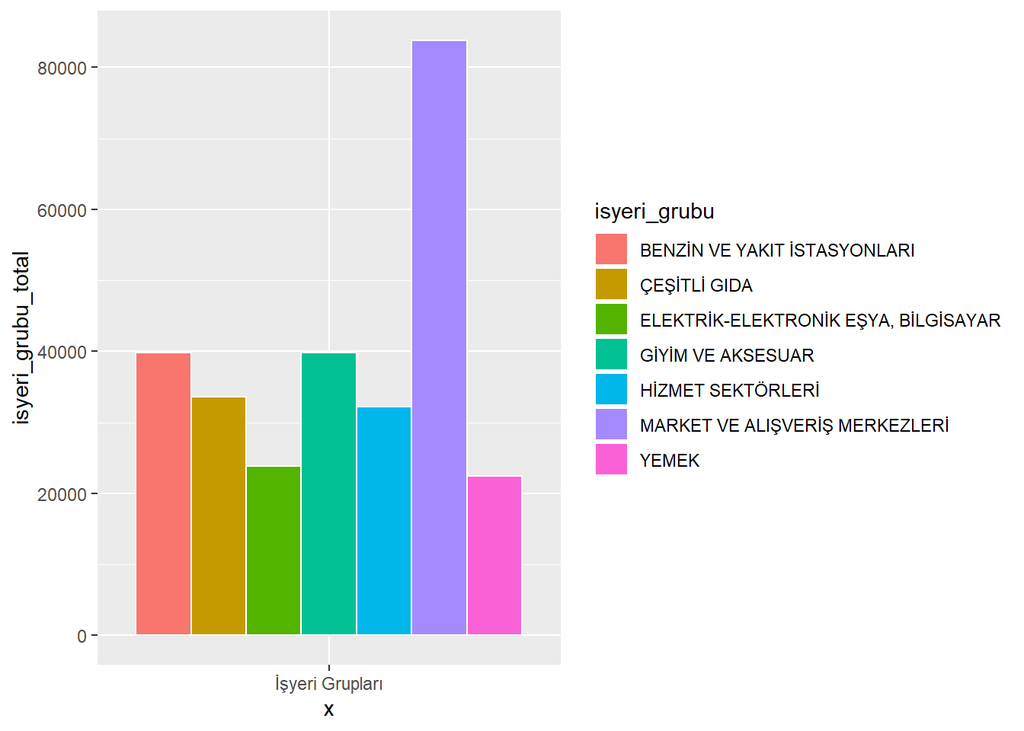

```r
tablo_son %>% select(isyeri_grubu,kredi_kartı_islem_tutarı,banka_kartı_islem_tutarı) %>%
  mutate(toplam_islem_tutarı = kredi_kartı_islem_tutarı + banka_kartı_islem_tutarı) %>%
  group_by(isyeri_grubu) %>% summarise(isyeri_grubu_total = sum(toplam_islem_tutarı)) %>%
  arrange(desc(isyeri_grubu_total))%>% filter(isyeri_grubu_total>20000)%>%
  ggplot(data = ., aes(x="İşyeri Grupları", y=isyeri_grubu_total, fill = isyeri_grubu)) +
  geom_bar(width = 1, stat = "identity", color = "white",position=position_dodge())
```

Highest seven sector according to their total card transaction amounts and how they changed in six months.

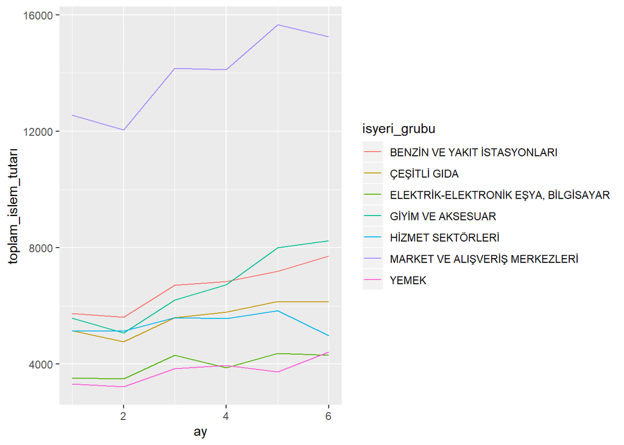

```r
highest_seven <- c("MARKET VE ALIŞVERİŞ MERKEZLERİ","GİYİM VE AKSESUAR","BENZİN VE YAKIT İSTASYONLARI","ÇEŞİTLİ GIDA","HİZMET SEKTÖRLERİ","ELEKTRİK-ELEKTRONİK EŞYA, BİLGİSAYAR","YEMEK")
tablo_son %>% filter(isyeri_grubu %in% highest_seven) %>%
  mutate(toplam_islem_tutarı = kredi_kartı_islem_tutarı + banka_kartı_islem_tutarı) %>%
  ggplot(aes(x=ay, y=toplam_islem_tutarı, color=isyeri_grubu)) +
  geom_line()
```

##### *Total Transaction Numbers and Share*

```r
tablo_son %>% select(isyeri_grubu,kredi_kartı_islem_adedi,banka_kartı_islem_adedi) %>%
  mutate(toplam_islem_adedi = kredi_kartı_islem_adedi + banka_kartı_islem_adedi) %>%
  group_by(isyeri_grubu) %>% summarise(isyeri_grubu_total = sum(toplam_islem_adedi)) %>%
  arrange(desc(isyeri_grubu_total)) %>%
  transmute(isyeri_grubu,isyeri_grubu_total,isyeri_grubu_total_fraction = round((isyeri_grubu_total / sum(isyeri_grubu_total))*100,1))
```

```
## # A tibble: 26 x 3
##    isyeri_grubu                  isyeri_grubu_total isyeri_grubu_total_fra~
##    <chr>                                      <dbl>                   <dbl>
##  1 MARKET VE ALIŞVERİŞ MERKEZLE~          957742221                    30.9
##  2 YEMEK                                  486166406                    15.7
##  3 ÇEŞİTLİ GIDA                           286302262                     9.2
##  4 BENZİN VE YAKIT İSTASYONLARI           228279355                     7.4
##  5 GİYİM VE AKSESUAR                      226946321                     7.3
##  6 HİZMET SEKTÖRLERİ                      174318580                     5.6
##  7 SAĞLIK/SAĞLIK ÜRÜNLERİ/KOZME~          132787104                     4.3
##  8 TELEKOMÜNİKASYON                       127338414                     4.1
##  9 DİĞER                                   88334580                     2.8
## 10 ELEKTRİK-ELEKTRONİK EŞYA, Bİ~           59837162                     1.9
## # ... with 16 more rows
```

Number of total transactions Gas Stations vs Service Sector in six month

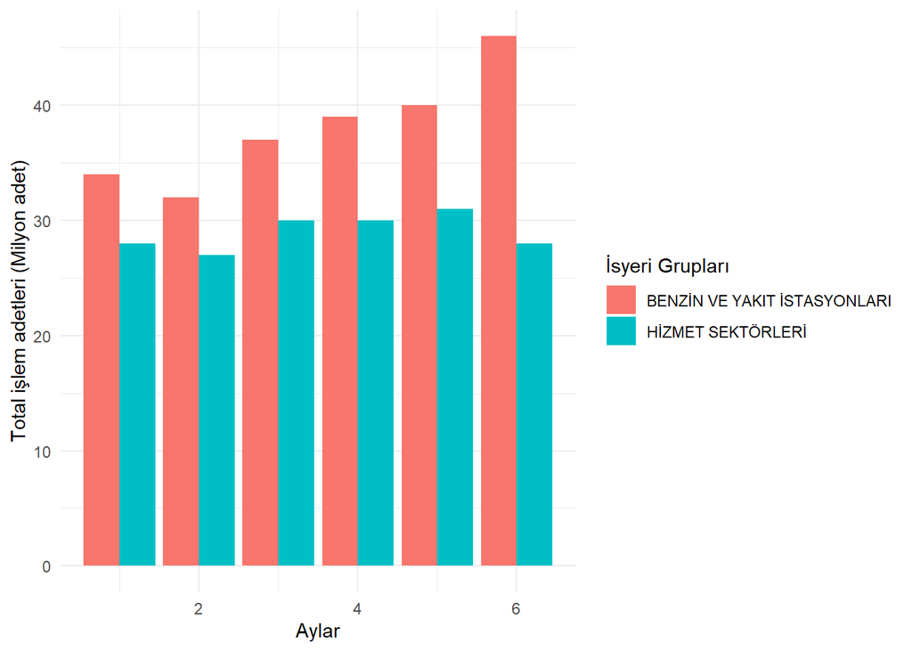

```r
tablo_son %>%
  select(isyeri_grubu,kredi_kartı_islem_adedi,banka_kartı_islem_adedi,ay)%>%
  mutate(total_kart_islem_adedi = kredi_kartı_islem_adedi + banka_kartı_islem_adedi)%>%
  group_by(isyeri_grubu, ay) %>%
  filter(isyeri_grubu %in% c("BENZİN VE YAKIT İSTASYONLARI", "HİZMET SEKTÖRLERİ")) %>%
  summarize(aylık_total_kart_islem_adedi = sum(total_kart_islem_adedi))%>%
  ggplot(data=., aes(x=ay, y=round(aylık_total_kart_islem_adedi/1000000,0), fill=isyeri_grubu)) +
  geom_bar(stat="identity", position=position_dodge())+
  labs(x="Aylar", y = "Total işlem adetleri (Milyon adet)", fill="İsyeri Grupları") +
  theme_minimal()
```